# Cointegration and Error Correction Models

Natasha Kang

Xiamen University, Chow Institute

April, 2026

## Regression with Time Series Data: What Was Assumed

In earlier discussions of regression with time series data, we used large-sample arguments for dependent observations.

> These arguments rely on stationarity of the underlying time series.

In many economic and financial time series, the data exhibit a clear **time trend**:

- output and income
- price levels
- population
- asset prices

## Regression with a Deterministic Time Trend

A natural first response is to include a time trend directly in the regression:

$$y_t = \beta_0 + \beta_1 x_t + \gamma t + u_t .$$

Here:

- $t$ captures systematic time evolution
- $x_t$ explains variation around the trend

Including a deterministic trend implies:

- the mean of $y_t$ changes smoothly over time
- the slope of the trend is fixed

Inference proceeds as in standard time series regression. This is, however, a **strong modeling assumption**.

## If the Trend Is Not Deterministic

When the nonstationarity in the data is **stochastic** rather than deterministic, including a time trend is no longer appropriate.

A common response is to **difference the data** to remove the stochastic trend.

For example, if $y_t$ is $I(1)$:

- levels are nonstationary
- first differences are stationary

Differencing,
$$\Delta y_t = y_t - y_{t-1},$$
reduces the order of integration by one.

## Can We Remove a Deterministic Trend by Differencing?

Consider
$$y_t = \alpha + \gamma t + \epsilon_t,$$
where $\epsilon_t$ is stationary.

Taking first differences,
$$\Delta y_t = \gamma + \epsilon_t - \epsilon_{t-1} = \gamma + (1-L) \epsilon_t$$

Differencing applies an unnecessary $(1-L)$ filter to a stationary component, producing an **over-differenced** process.

The MA polynomial $(1-L)$ has a unit root, so $\Delta y_t$ inherits a **noninvertible** MA component — the formal sense in which the series has been over-differenced.

## Can We Remove a Stochastic Trend by Detrending?

Consider
$$y_t = y_{t-1} + \alpha_0 + \epsilon_t,$$
where $\epsilon_t$ is stationary.

This can be written equivalently as
$$y_t = y_0 + \alpha_0 t + \sum_{i=1}^t \epsilon_i .$$

Subtracting the deterministic component $y_0 + \alpha_0 t$ removes the linear drift, but the accumulated shocks $\sum_{i=1}^t \epsilon_i$ remain. Therefore, detrending **cannot** remove a stochastic trend.

## Choosing the Right Transformation

The appropriate transformation depends on the nature of the trend.

- If the trend is **deterministic**:
  - detrending is sufficient
  - differencing is inappropriate and leads to over-differencing
- If the trend is **stochastic**:
  - detrending fails
  - differencing may be required to restore stationarity

In practice, the nature of the trend is unknown.

This motivates the need for tools that help distinguish deterministic from stochastic trends — namely, **unit root testing**.

## A Critique of Differencing

Differencing restores stationarity, but it removes the low-frequency variation that is often central to macroeconomic questions.

As a result:

- permanent movements in levels are removed
- long-run comovement between variables is no longer visible
- relationships in levels cannot be identified

After differencing, regression coefficients describe how **changes** in the dependent variable are related to changes (or levels) of the regressors, not how their levels move together over time.

> This concern is emphasized in Christopher A. Sims’ critique of routine differencing and pre-testing in macroeconometric practice.

## What If We Do Not Difference?

Consider a regression using variables in levels:

$$y_t = \beta x_t + u_t,$$
where $x_t$ and $y_t$ are nonstationary.

## Example: Two Nonstationary Series in Levels

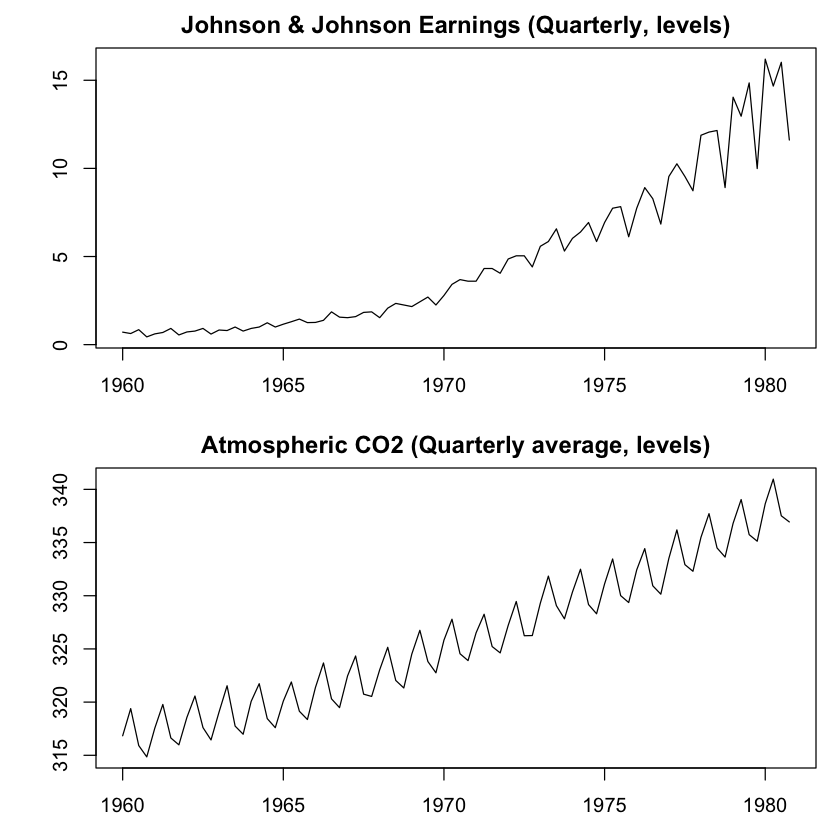

### OLS Regression in Levels

```
Table: OLS regression in levels

|Term        | Estimate| Std.Error| t.stat| p.value|
|:-----------|--------:|---------:|------:|-------:|
|(Intercept) |  -190.03|      7.69| -24.70|  <1e-04|
|co2         |     0.60|      0.02|  25.33|  <1e-04|
```

The coefficient on $x_t$ is highly significant — but should we believe it?

## Can We Trust Statistical Association in Levels?

In the late 19th and early 20th centuries, statistics was primarily used to **describe and compare social conditions over time**.

Governments, churches, and public institutions began collecting long time series on:

- church attendance, as a measure of religiosity and moral behavior
- drunkenness or alcohol consumption, as indicators of social disorder
- poverty, population, and mortality, as measures of social welfare

As these long time series became available, researchers naturally began using **correlation** to assess whether different indicators moved together over time.

Correlation was often interpreted as evidence consistent with a causal relationship, and used to inform policy or intervention.

## Why the Patterns Looked Real

These associations were often:

- large in magnitude
- stable over time
- regarded as strong and non-negligible by the statistical standards of the time

The difficulty was not that any single relationship was obviously absurd, but that **almost everything appeared related to everything else**.

## Yule’s Diagnosis: “Nonsense Correlation”

**Yule (1926)** was among the first to articulate this problem clearly.

He noted that when time series exhibit strong persistence, large correlations can arise **mechanically**, even when the underlying series are unrelated.

Yule referred to this phenomenon as *“nonsense correlation.”*

## Spurious Regression

As regression methods became standard from the 1960s onward, researchers increasingly fit relationships between time series in **levels**:
$$y_t = \beta x_t + u_t.$$

**Granger and Newbold (1974)** showed that even when $x_t$ and $y_t$ are unrelated, such regressions can produce:

- large $t$-statistics
- high $R^2$
- persistent residuals

This phenomenon became known as **spurious regression**.

## Illustration: Independent Persistent Series

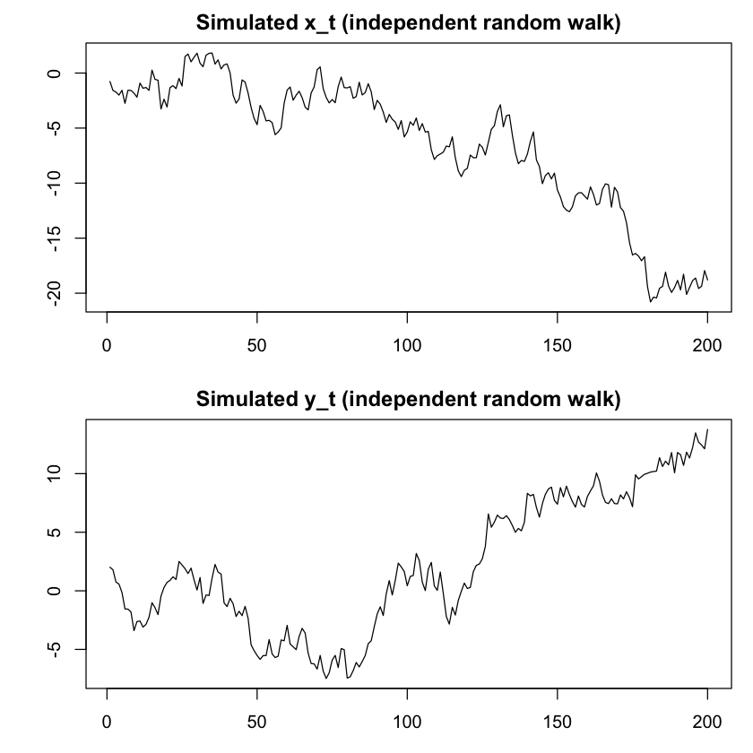

## Spurious Regression: OLS Output

```
|            | Estimate| Std. Error| t value| p-value|
|:-----------|--------:|----------:|-------:|-------:|
|(Intercept) |   -2.790|      0.347|   -8.03|       0|
|x           |   -0.762|      0.039|  -19.44|       0|
```

Despite $x_t$ and $y_t$ being **independent**, OLS reports a highly significant coefficient and a large $R^2$.

## Illustration: Cointegrated vs Independent Series

A preview: the right-hand column shows a case where the residual is stable — **cointegration**, defined formally in the next section.

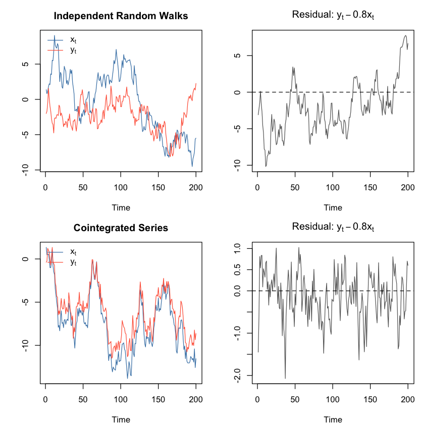

### Spurious $R^2$

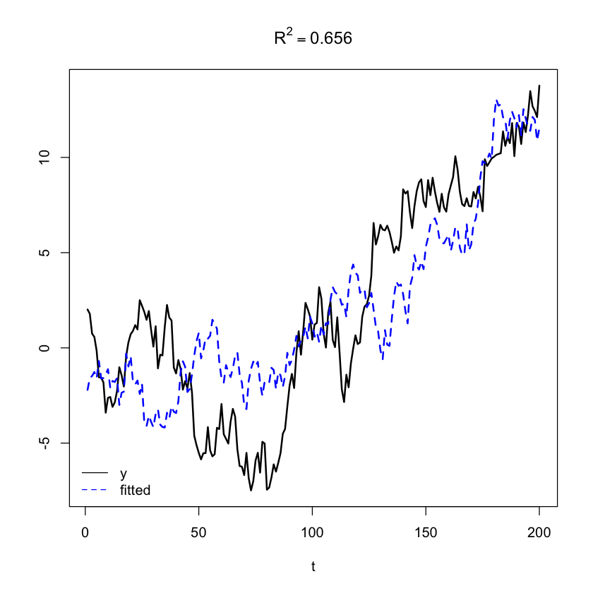

### Residual Persistence in Spurious Regression

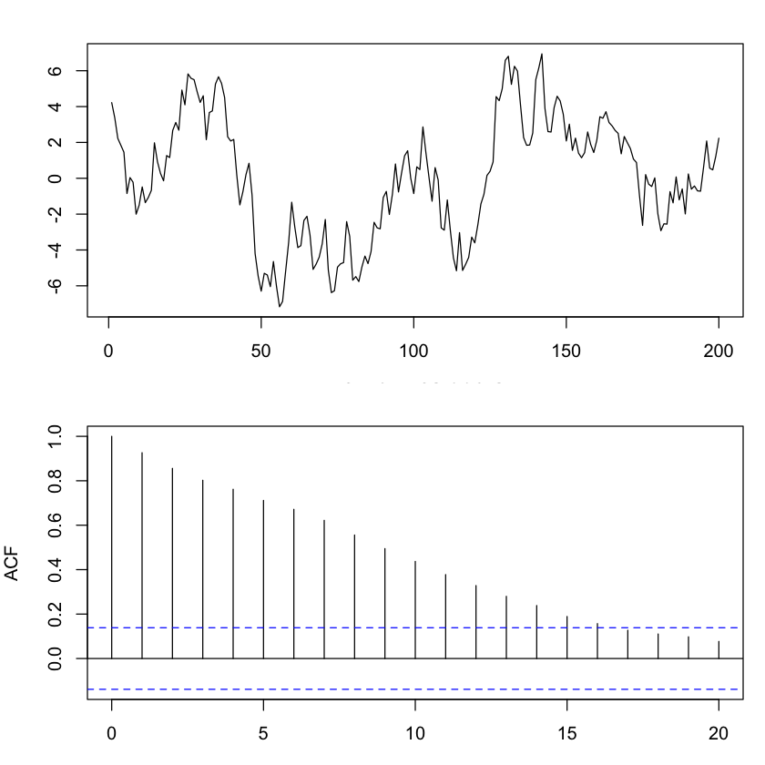

## Nonstationary Residuals

The **problem** of spurious regression lies in the residual $\{\hat{u}_t\}$ (ignoring the intercept):

$$\hat{u}_t = y_t - \hat{\beta} x_t .$$

Suppose the variables follow random walks:
$$y_t = \sum_{i=1}^t \xi_i,
\qquad
x_t = \sum_{i=1}^t \eta_i,$$
where $\{\eta_i\}$ and $\{\xi_i\}$ are independent, mean-zero innovations.

## The Residual Inherits a Unit Root

The residual then behaves like
$$\hat{u}_t
\;\approx\;
\sum_{i=1}^t \xi_i
\;-\;
\hat{\beta} \sum_{i=1}^t \eta_i .$$

- The residual process is **nonstationary** (contains a unit root component).
- This violates the assumptions underlying standard OLS inference.

## Illustration: Same Data, After Differencing

```
Table: Regression in first differences

|            | Estimate| Std. Error| t value| Pr(>&#124;t&#124;)|
|:-----------|--------:|----------:|-------:|------------------:|
|(Intercept) |    0.063|      0.069|   0.908|              0.365|
|diff(x)     |    0.044|      0.071|   0.616|              0.539|
```

Differencing eliminates the spurious significance — but also any information about the long-run levels.

## When Is a Levels Regression Not Spurious?

So far, we have seen that:

- regressions in levels with nonstationary data are unreliable
- differencing removes the problem, but also removes long-run information

There is, however, an important exception.

If **a linear combination of nonstationary variables is stationary**, then a regression in levels can be meaningful.

## Cointegration

Suppose $x_t$ and $y_t$ are both nonstationary.

They are said to be **cointegrated** if there exists a coefficient $\beta$ such that

$$y_t - \beta x_t$$

is stationary.

- the variables may wander individually
- but they do not drift arbitrarily far apart
- deviations from the long-run relationship are stable

## Cointegration: Economic Motivation

Before the statistical consequences of nonstationarity were widely understood, empirical macroeconomics routinely analyzed key variables in levels.

By the late 1970s, this practice faced a tension:

- many macroeconomic time series appeared to be nonstationary
- differencing restored statistical validity
- but economic analysis often focused on **long-run relationships in levels**

Examples of relationships historically analyzed in levels include:

- consumption and income, studied as long-run co-moving aggregates
- money supply and the price level, central to monetary equilibrium analysis
- nominal interest rates at different maturities, where yield spreads are often stable
- exchange rates and relative prices, motivated by long-run parity conditions

## Consumption and Income (Permanent Income Hypothesis)

The permanent income hypothesis (Friedman) states that households choose consumption based on **long-run (permanent) income**, not on short-run income fluctuations.

Income is decomposed as
$$y_t = y_t^{p} + y_t^{tr},$$
where:

- $y_t^{p}$ is permanent income
- $y_t^{tr}$ is transitory income

Consumption is decomposed analogously:
$$c_t = c_t^{p} + c_t^{tr}.$$

## PIH: Behavioral Assumption and Cointegration

The key behavioral assumption of PIH is:
$$c_t^{p} = \beta \, y_t^{p},$$
with transitory consumption $c_t^{tr}$ assumed to be stationary.

This implies
$$c_t = \beta y_t^{p} + c_t^{tr},$$
so that $c_t$ and $y_t^{p}$ may be nonstationary, but deviations from their long-run relationship are stable.

## Monetary Equilibrium (Money, Prices, and Income)

In the long run, the **money market clears**:
$$\text{money supply} = \text{money demand}.$$

The behavioral side of this equilibrium is given by the **liquidity theory of money demand**:
$$\frac{M_t}{P_t} = L(Y_t, i_t),$$
where real money balances demanded depend on real income and interest rates.

## Monetary Equilibrium as Cointegration

In logs, the long-run equilibrium condition can be written as
$$m_t - p_t = \beta_0 + \beta_1 y_t + \beta_2 i_t + u_t.$$

If money supply, prices, and income are $I(1)$, monetary equilibrium requires the disequilibrium term
$$u_t = (m_t - p_t) - \beta_1 y_t - \beta_2 i_t - \beta_0$$
to be stationary.

This implies cointegration among money, prices, and income.

## Term Structure of Interest Rates

Let $r_t^{(n)}$ denote the nominal interest rate on an $n$-period bond and $r_t^{(1)}$ the one-period (short-term) rate.

Term structure theory implies that long and short rates are linked by a stable long-run relationship. In particular, the yield spread
$$s_t^{(n)} \equiv r_t^{(n)} - r_t^{(1)}$$
reflects expectations of future short rates and **term premia**.

Empirically, individual interest rates are often highly persistent and are reasonably characterized as $I(1)$ processes.

If term structure theory is correct in the long run, the spread $s_t^{(n)}$ should be stable, implying
$$r_t^{(n)} - r_t^{(1)} \sim I(0).$$

Thus, $r_t^{(n)}$ and $r_t^{(1)}$ are cointegrated, with the yield spread as the equilibrium error.

## Purchasing Power Parity (PPP)

Purchasing power parity posits a long-run relationship between nominal exchange rates and relative price levels.

In levels, absolute PPP implies
$$S_t = \frac{P_t}{P_t^*},$$
where $S_t$ is the nominal exchange rate (domestic price of foreign currency).

Taking logs,
$$s_t = p_t - p_t^*.$$

Empirically, exchange rates and price levels are often highly persistent and are reasonably characterized as $I(1)$ processes.

## PPP as Cointegration

If PPP holds as a long-run equilibrium condition, the real exchange rate
$$q_t \equiv s_t - (p_t - p_t^*)$$
should be stable, implying
$$q_t \sim I(0).$$

Thus, $s_t$, $p_t$, and $p_t^*$ are cointegrated, with the real exchange rate as the equilibrium error.

## Cointegration (Engle and Granger, 1987)

Let $x_t = (x_{1t}, \ldots, x_{kt})'$ be a vector of time series.

The components of $x_t$ are said to be **cointegrated of order $(d,b)$**, denoted $x_t \sim CI(d,b)$, if:

1. Each component of $x_t$ is integrated of order $d$.
2. There exists a nonzero vector $\beta \in \mathbb{R}^k$ such that
   $$\beta' x_t \sim I(d-b), \qquad 0 < b \le d.$$

The vector $\beta$ is called a **cointegrating vector**. In most macroeconomic applications, we focus on the case
$$CI(1,1),$$
where individual series are $I(1)$ but the equilibrium error $\beta' x_t$ is stationary.

## Non-Uniqueness of Cointegrating Vectors

Suppose $x_t \sim CI(d,b)$ and there exists a cointegrating vector $\beta \neq 0$ such that
$$\beta' x_t \sim I(d-b).$$

For any nonzero scalar $c \neq 0$,
$$(c\beta)' x_t = c(\beta' x_t) \sim I(d-b).$$

Cointegrating vectors are **not unique**. Only the **cointegrating space** is uniquely defined.

## Normalization of Cointegrating Vectors

To express the long-run restriction in a convenient form, a **normalization** is imposed.

A common normalization sets one coefficient equal to one. For example, if
$$\beta_1 y_t + \beta_2 x_t \sim I(0),$$
we may normalize on $y_t$:
$$y_t - \theta x_t \sim I(0),
\qquad \theta = -\beta_2 / \beta_1.$$

Different normalizations represent the **same equilibrium condition**.

## Cointegrating Rank

So far we have considered a single long-run relationship between two variables. With more than two variables, several relationships may hold simultaneously.

Let $x_t$ be a $k \times 1$ vector of time series, with each component integrated of order $d$.

Suppose there exist $r$ linearly independent vectors
$$\beta_1, \ldots, \beta_r$$
such that
$$\beta_i' x_t \sim I(d-b), \qquad i = 1,\ldots,r.$$

Then $x_t$ is said to have **cointegrating rank $r$**.

When $r = 1$, the cointegrating vector is unique up to scale (normalization).

When $r > 1$, there are **multiple linearly independent cointegrating relationships**.

## Cointegrating Rank: Special Cases

- $r = 0$: no cointegration
- $r = 1$: a single long-run equilibrium relationship
- $1 < r < k$: multiple long-run equilibrium restrictions
- $r = k$: every direction in $\mathbb{R}^k$ is a cointegrating combination, so each $x_{it}$ is itself $I(0)$ (applies when $d=b=1$)

## Cointegrating Rank: Interpretation

Rank can exceed one when **multiple long-run relations hold simultaneously** in the same system.

For example, in a monetary system:

- a long-run money demand relation implies
  $$m_t - \beta_0 - \beta_1 p_t - \beta_2 y_t - \beta_3 r_t \sim I(0)$$
- a monetary policy feedback rule, where the central bank adjusts nominal money supply in response to nominal GDP, implies
  $$m_t - \gamma_0 + \gamma_1 (y_t + p_t) \sim I(0)$$

## Cointegrating Rank: Monetary System Example

Writing
$$x_t = (m_t,\; 1,\; p_t,\; y_t,\; r_t)',$$
we follow the standard convention of augmenting the stochastic variables with a constant so that intercepts are included in the cointegrating relations. Cointegration itself concerns the stochastic variables $(m_t,p_t,y_t,r_t)$.

These relations correspond to the cointegrating vectors

$$\beta^{(1)} = (1 ,\; -\beta_0,\; -\beta_1,\; -\beta_2,\; -\beta_3)',
\qquad
\beta^{(2)} = (1,\; -\gamma_0,\; \gamma_1,\; \gamma_1,\; 0)'.$$

Since the vectors are linearly independent, the cointegrating rank is $r=2$.

## Cointegration and Common Stochastic Trends

By the 1960s–70s, empirical researchers observed that many macroeconomic time series were highly persistent and moved together over long horizons.

This raised a descriptive question:

> Are these variables sharing the same long-run sources of persistence, or does each variable drift independently?

## A Factor Representation

One way to formalize this question is to consider the representation
$$x_t = \Lambda f_t + e_t,$$
where:

- $x_t$ is an $n \times 1$ vector of observed variables
- $f_t$ is a $k \times 1$ vector of persistent ($I(1)$) components
- $\Lambda$ is an $n \times k$ loading matrix of full column rank
- $e_t$ is an $n \times 1$ stationary component

## Common Trends and Cointegrating Rank

If there exists a nonzero vector $\beta \in \mathbb{R}^n$ such that $\beta’ x_t \sim I(0)$, then substituting the factor representation,
$$\beta’ x_t = \beta’ \Lambda f_t + \beta’ e_t.$$

Since $\beta’ e_t$ is $I(0)$ and $f_t$ is $I(1)$, the sum can be $I(0)$ only if
$$\beta’ \Lambda = 0.$$

That is, $\beta$ eliminates the $k$ persistent components. This is possible only if $k < n$.

The number of such linearly independent $\beta$’s is $n-k$, which corresponds to the cointegrating rank.

## Cointegration and Error Correction Models

We now turn from characterizing cointegration to its dynamic implications.

Cointegration is a restriction on **long-run behavior**.

> It implies that while variables may drift over time, they cannot drift arbitrarily far apart.

Equivalently, deviations from the long-run relation must be **temporary**.

For example, let
$$z_{t-1} \equiv y_{t-1} - \beta x_{t-1}$$
denote the equilibrium error.

If $\{z_t\}$ is stationary, then it is **mean reverting**: when the system is out of equilibrium, adjustment must occur to restore the long-run relation.

## The Error Correction Model

The equilibrium error evolves from one period to the next as
$$\Delta z_t = \Delta y_t - \beta \, \Delta x_t.$$

So when the system is out of equilibrium ($z_{t-1} \ne 0$), the correction can only come through $\Delta y_t$ and $\Delta x_t$ — these are the only channels by which the error can move.

A dynamically coherent specification is therefore
$$\begin{aligned}
\Delta y_t &= \alpha_y \, z_{t-1} + \varepsilon_{y,t}, \\
\Delta x_t &= \alpha_x \, z_{t-1} + \varepsilon_{x,t},
\end{aligned}$$
which is called an **error correction model (ECM)**.

- $z_{t-1}$ measures the **extent of disequilibrium**
- $\alpha_y$ and $\alpha_x$ are **speed-of-adjustment parameters**, describing the direction and strength of adjustment

## Weak Exogeneity

If $\alpha_y = 0$, then $y_t$ does not respond to disequilibrium.

All error correction occurs through $x_t$.

In this case, $y_t$ is said to be **weakly exogenous**: it does not participate in error correction.

## Error Correction Model: General Form

In practice, short-run dynamics may involve lags, intercepts, and additional covariates.

A general single-equation ECM can be written as
$$\Delta y_t
=
\alpha\, z_{t-1}
+ c
+ \sum_{i=1}^p \phi_i \, \Delta y_{t-i}
+ \sum_{j=0}^q \psi_j \, \Delta x_{t-j}
+ \varepsilon_t,$$
where
$$z_{t-1} = y_{t-1} - \beta x_{t-1}.$$

- $z_{t-1}$ captures **long-run disequilibrium**
- differenced terms capture **short-run dynamics**
- the constant allows for **deterministic drift**
- the ECM combines long-run restrictions with short-run flexibility

## Super-Consistency of the Cointegrating Regression

Before we estimate $\beta$ by OLS in levels, we need to know whether OLS produces a usable estimate when the regressors are nonstationary.

In a standard stationary regression, OLS converges at rate $\sqrt{T}$:
$$\hat\beta - \beta = O_p(T^{-1/2}).$$

In a cointegrating regression between $I(1)$ variables, OLS converges at rate $T$:
$$\hat\beta - \beta = O_p(T^{-1}).$$

This is **super-consistency**: the estimator converges much faster because $\sum_{t=1}^T x_t^2 = O_p(T^2)$ when $x_t$ is $I(1)$ (versus $O_p(T)$ when stationary), and the OLS denominator scales accordingly.

## Engle–Granger Two-Step: Step 1

**Estimate the long-run relationship.**

Estimate the cointegrating relation in levels:
$$y_t = \beta x_t + u_t.$$

Obtain the estimated equilibrium error:
$$\hat z_t = y_t - \hat\beta x_t.$$

## Engle–Granger Two-Step: Step 2

**Estimate the short-run dynamics.**

Fit the ECM using differenced data and the lagged equilibrium error:
$$\Delta y_t
=
\alpha \hat z_{t-1}
+ \sum_{i=1}^p \phi_i \Delta y_{t-i}
+ \sum_{j=0}^q \psi_j \Delta x_{t-j}
+ \varepsilon_t.$$

## Cointegration Test: Engle–Granger

Assume both $x_t$ and $y_t$ are $I(1)$.

Because $\hat\beta$ is super-consistent, the estimated residual $\hat u_t = y_t - \hat\beta x_t$ inherits the stationarity properties of the true equilibrium error.

The Engle–Granger test inverts the spurious-regression logic: if $x_t$ and $y_t$ are cointegrated, $\hat u_t$ should be **stationary**.

Suppose we estimate the levels regression
$$y_t = \beta x_t + u_t,$$
and define the residual $\hat u_t \equiv y_t - \hat\beta x_t$.

- If $\hat u_t$ is nonstationary, the regression is **spurious**
- If $\hat u_t$ is stationary, $x_t$ and $y_t$ are **cointegrated**

## Engle–Granger Test Procedure

The **Engle–Granger test** checks whether $\hat u_t$ contains a unit root by running an ADF regression on the residuals:
$$\Delta \hat u_t = \rho\, \hat u_{t-1} + \sum_{i=1}^{p} \phi_i \Delta \hat u_{t-i} + e_t,$$
and testing $H_0: \rho = 0$ (unit root in residuals, i.e., no cointegration).

Because $\hat u_t$ is constructed using an estimated coefficient, the test uses **critical values different from the usual Dickey–Fuller tables**.

## A Limitation of the Engle–Granger Approach

Cointegration is a **symmetric property**: either $x_t$ and $y_t$ share a stationary linear combination, or they do not.

The Engle–Granger procedure is **asymmetric by construction** because it relies on a *single OLS projection*.

Consider two independent $I(1)$ processes:
$$x_t = x_{t-1} + \eta_t,
\qquad
y_t = y_{t-1} + \xi_t,$$
with $\{\eta_t\}$ and $\{\xi_t\}$ i.i.d., mean zero, and uncorrelated.

## Asymmetry of the Engle–Granger Procedure

Equivalently,
$$x_t = \sum_{i=1}^t \eta_i,
\qquad
y_t = \sum_{i=1}^t \xi_i.$$

Estimate the levels regression
$$y_t = \beta x_t + \varepsilon_t$$
by OLS.

OLS chooses $\hat\beta$ to minimize
$$\sum_{t=1}^T (y_t - \beta x_t)^2,$$
that is, it projects the entire path of $y_t$ onto the path of $x_t$.

The resulting residual is
$$\hat u_t
= y_t - \hat\beta x_t
= \sum_{i=1}^t \xi_i - \hat\beta \sum_{i=1}^t \eta_i
= \sum_{i=1}^t (\xi_i - \hat\beta \eta_i).$$

## Reversing the Regression

If instead we reverse the roles and estimate
$$x_t = \gamma y_t + \nu_t,$$
OLS now projects the path of $x_t$ onto the path of $y_t$, producing
$$\hat\nu_t
= \sum_{i=1}^t (\eta_i - \hat\gamma \xi_i),$$
which is a **different stochastic process**.

In finite samples, $\hat\gamma \ne 1/\hat\beta$, since each OLS minimizes a different sum of squares.

### Why test outcomes may differ

- Under **no cointegration**, *any* residual constructed from nonstationary regressors is nonstationary **in population**.
- The Engle–Granger test is a **finite-sample procedure**: it evaluates whether the estimated residual *appears* sufficiently mean-reverting.
- Different OLS projections absorb different amounts of low-frequency variation, so residuals can exhibit **different degrees of persistence** in finite samples.
- As a result, unit root tests applied to these residuals can yield **different outcomes**, even though the underlying variables are not cointegrated.

## Where We Landed

- **Problem:** regressions in levels with trending data produce spurious results — large $t$-statistics, high $R^2$, persistent residuals.
- **Partial fix:** differencing restores stationarity but eliminates the long-run information that is often the object of interest.
- **Resolution:** cointegration — when a stationary linear combination exists, a levels regression recovers the long-run relationship.
- **Operational tool:** the ECM combines long-run restrictions with short-run dynamics; the Engle–Granger test checks whether cointegration holds.

## Looking Ahead

The Engle–Granger approach handles **one** cointegrating relation between **two** variables.

For systems with multiple variables and potentially multiple cointegrating relations:

- **Vector Error Correction Models (VECM)** generalize the ECM to systems
- The **Johansen procedure** tests for cointegrating rank by estimating the number of common stochastic trends
- **Next: Vector Autoregressions and VECM**